# Forecast on climate in New Dehli

16 oktober 2019

## Background

- I wanted to re-use the work I did in my master thesis on new data.
- In the thesis I wrote my own functions for doing Bayesian vector autoregression which I applied on data from an A/B-test. The goal then was to early try to see the long term effects.
- Now I will use data on the climate in New Dehli which I downloaded from Kaggle.
- I have changed some things on my original code so I now also include seasonal effects and trend.
- First I will forecast based on the existing train-dataset and compare my predictions against the existing test-dataset. Then I will use less data in the train-dataset which I move to the test-dataset to see the performance for longer forecasts.

## First glimpse of the data

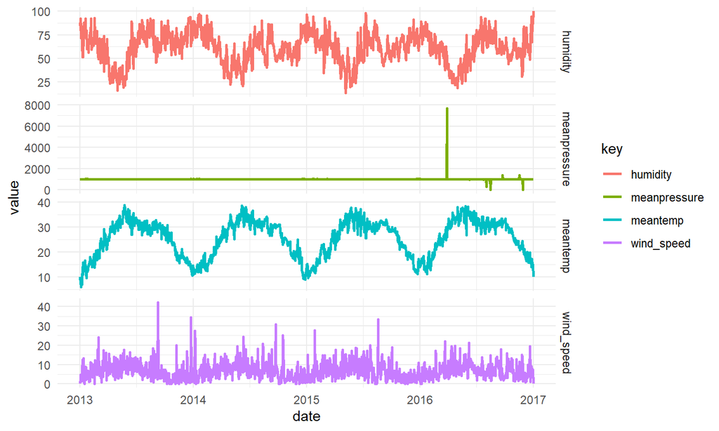

## Removing outliers

Removing dates where "meanpressure" < 950 or "meanpressure" > 1050

```
##   filtered_out_obs
## 1                9
```

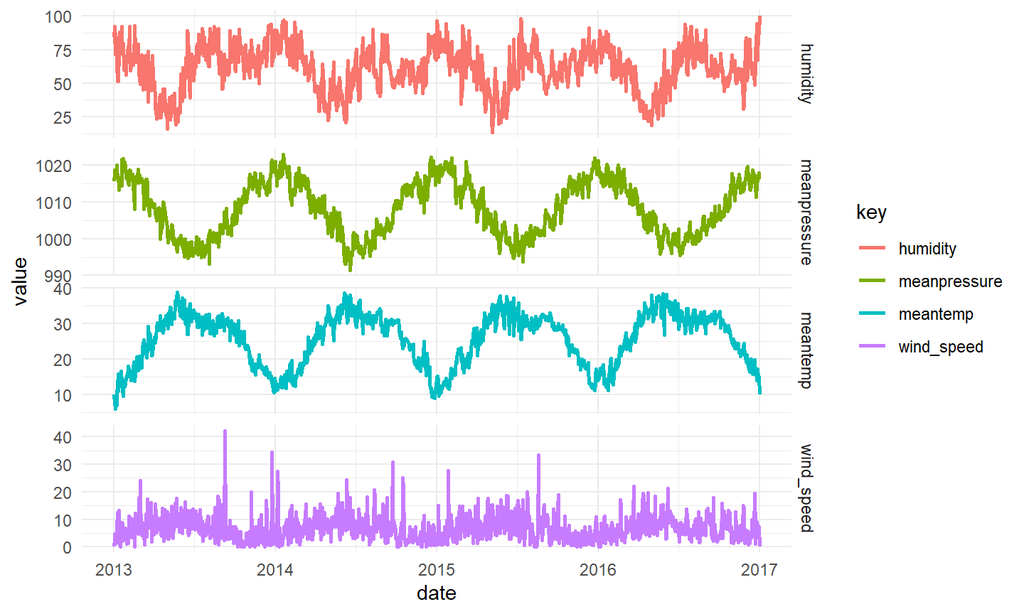

## Monthly seasonal effects

Average values for each months shows all four feature has seasonal effects

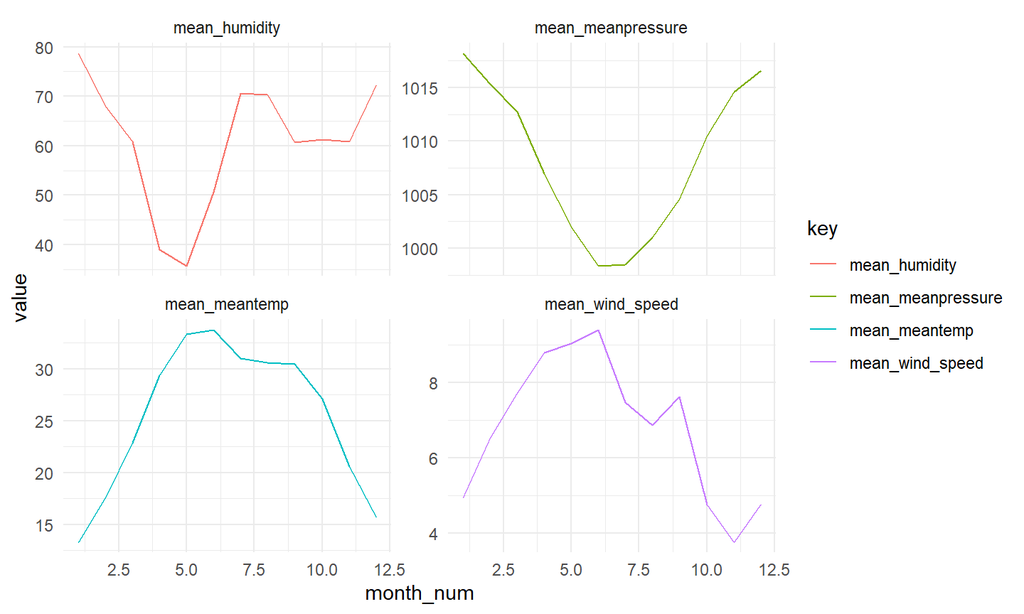

## Features correlates with each other and have little trend effect

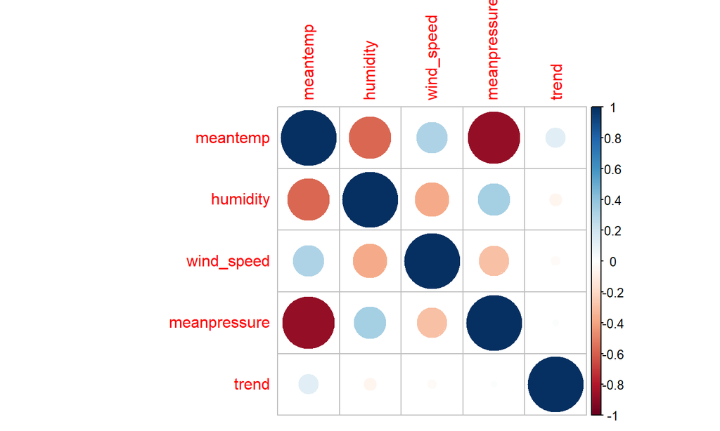

## Notes after exploration

- Feature "meanpressure" has 9 outliers which we removes
- There is a seasonality effect
- The features correlates with each other which is good for when building a Bayesian vector autoregression-model
- "temp" and "humidity" has a small correlation with time

## It's time to forecast!

- Vector auoregression (VAR) uses all the metrics past values when forcasting.
- We will use a Bayesian approach with non-informative priors which lower the risk of overfitting
- Bayesian vector autoregression (BVAR) use gipps sampling which generates samples from a posterior multivariate distribution. For each prediction we will estimate the dates posterior distribution with 1000 samples.

## Forecast

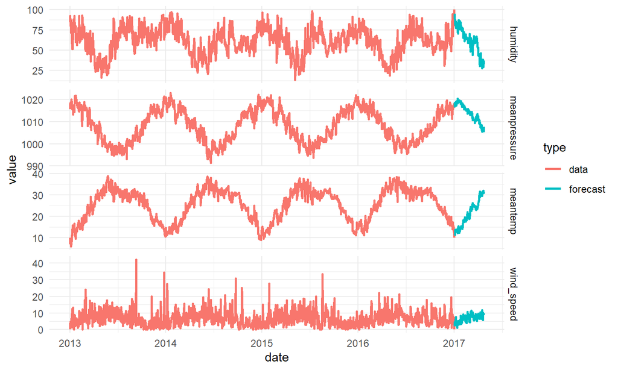

## Estimation with its 95% confidence intervalls compared to real data

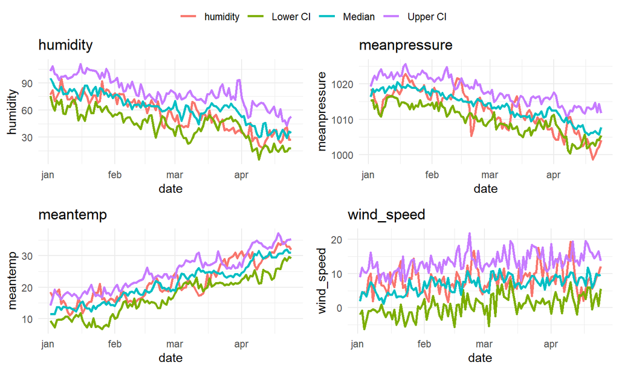

## Forecasting a longer period

I have now moved all the data from 2016 to the test-dataset because I wanted to test forecasting a longer period

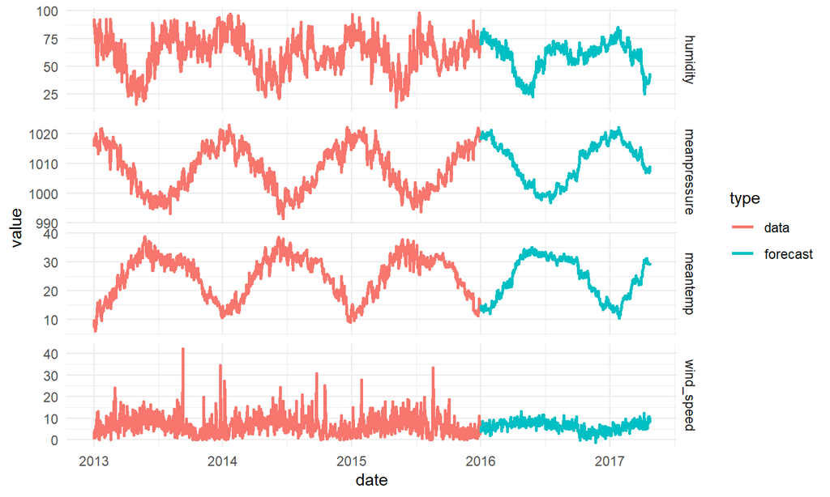

## Estimation with its 95% confidence intervalls compared to real data

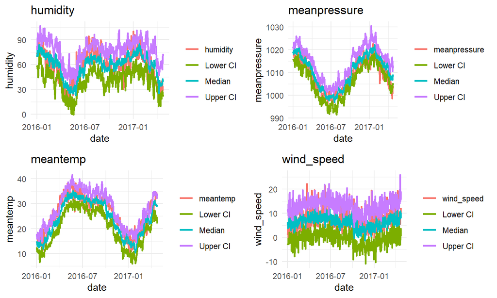

## Summary

- Perhaps this dataset wasn't the most challenging and you could probably solved this with a much easier method. But the purpose with this project was to play around with the code I used in my master thesis just for fun.
- If we tried some other methods we could compare the methods against each other by evaluating some metrics like for example mean square error.